# Fan Ratings

Steven Miller

April 6, 2019

## Fan Ratings Dataset

```r
ratings <- read.csv('data/fan_ratings.csv')
```

Summary of Fan Ratings:

```r
summary(ratings)
```

```
##        Y              R                    GPNAME           P1
##  Min.   :2008   Min.   : 1.000   Australian GP: 11   Hamilton:62
##  1st Qu.:2010   1st Qu.: 5.000   Belgian GP   : 11   Vettel  :52
##  Median :2013   Median :10.000   British GP   : 11   Rosberg :22
##  Mean   :2013   Mean   : 9.822   Chinese GP   : 11   Button  :14
##  3rd Qu.:2016   3rd Qu.:14.000   Hungarian GP : 11   Alonso  :13
##  Max.   :2018   Max.   :21.000   Monaco GP    : 11   Webber  : 9
##                                  (Other)      :136   (Other) :30
##          P2             P3         RATING
##  Hamilton :30   Raikkonen:26   Min.   :3.740
##  Vettel   :29   Vettel   :26   1st Qu.:5.777
##  Rosberg  :25   Hamilton :21   Median :6.812
##  Alonso   :19   Alonso   :16   Mean   :6.793
##  Raikkonen:19   Ricciardo:15   3rd Qu.:7.801
##  Webber   :16   Webber   :15   Max.   :9.449
##  (Other)  :64   (Other)  :83
```

Y - Year of Race R - Round of Race in Season GPNAME - Name of Race P1 - Race Winner P2 - Runner-Up P3 - Third Place RATING - Average fan rating on a scale from 1 to 10

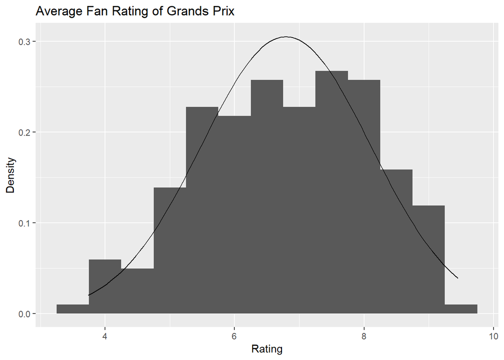

```r
ggplot(ratings, aes(RATING)) + geom_histogram(aes(y=..density..), binwidth = 0.5) +
  stat_function(fun = dnorm, args = list(mean = mean(ratings$RATING), sd = sd(ratings$RATING))) +
  labs(title="Average Fan Rating of Grands Prix", y="Density", x="Rating")
```

Is it possible that certain drivers winning a race would have an impact on the fan rating? It seems like a possibility to me. A fan of a certain driver might be more likely to give a race a higher rating if they enjoyed the race. Looking at the summary of the ratings table, it appears that the five winningest drivers in the data set were Hamilton, Vettel, Rosberg, Button, and Alonso. We also know that the mean rating is 6.793. Let’s see what the average rating is for races where these drivers won.

```r
agg <- aggregate(ratings$RATING, by = list(ratings$P1), FUN = mean)
agg <- agg[order(-agg$x),]
names(agg) <- c("Driver","Rating")
print(agg)
```

```
##        Driver   Rating
## 8   Maldonado 8.274000
## 11  Ricciardo 8.108571
## 7      Kubica 7.809000
## 13 Verstappen 7.732500
## 4      Button 7.307286
## 10  Raikkonen 7.045400
## 5    Hamilton 6.945645
## 1      Alonso 6.799077
## 14     Vettel 6.569173
## 15     Webber 6.517000
## 12    Rosberg 6.449364
## 2  Barichello 6.202000
## 6  Kovalainen 6.202000
## 9       Massa 6.104333
## 3      Bottas 4.836667
```

Recalling that our mean rating was 6.793 it appears that the five winningest drivers are all pretty close to this mean. From this, one could hypothesize that fans find it more or less exciting when a driver who doesn’t typically win races wins.

## Ergast F1 Dataset

The first variable we’ll take a look at is the duration of pit stops. Throughout many seasons, the rules regarding pit stops have changed. Over time, various seasons of racing will have had various average durations for pit stops. This can be a matter of seconds but leads to big changes in strategic decision making that can impact the way a race plays out.

```r
pitstops <- read.csv('data/pit_stops.csv', header=FALSE, col.names = c("raceId","driverId","stop","lap","time","duration","milliseconds"))
summary(pitstops)
```

```
##      raceId          driverId          stop            lap
##  Min.   : 841.0   Min.   :  1.0   Min.   :1.000   Min.   : 1.00
##  1st Qu.: 871.0   1st Qu.: 16.0   1st Qu.:1.000   1st Qu.:13.00
##  Median : 909.0   Median :807.0   Median :2.000   Median :24.00
##  Mean   : 915.9   Mean   :447.4   Mean   :1.793   Mean   :24.83
##  3rd Qu.: 959.0   3rd Qu.:822.0   3rd Qu.:2.000   3rd Qu.:35.00
##  Max.   :1011.0   Max.   :848.0   Max.   :6.000   Max.   :74.00
##
##        time         duration     milliseconds
##  14:56:46:   5   22.303 :   6   Min.   :  12897
##  14:05:02:   4   22.838 :   6   1st Qu.:  21811
##  14:18:36:   4   21.012 :   5   Median :  23375
##  14:19:03:   4   21.900 :   5   Mean   :  45738
##  14:20:17:   4   22.105 :   5   3rd Qu.:  25567
##  14:20:51:   4   22.273 :   5   Max.   :2011266
##  (Other) :6824   (Other):6817
```

```r
head(pitstops)
```

```
##   raceId driverId stop lap     time duration milliseconds
## 1    841      153    1   1 17:05:23   26.898        26898
## 2    841       30    1   1 17:05:52   25.021        25021
## 3    841       17    1  11 17:20:48   23.426        23426
## 4    841        4    1  12 17:22:34   23.251        23251
## 5    841       13    1  13 17:24:10   23.842        23842
## 6    841       22    1  13 17:24:29   23.643        23643
```

raceId - the database id of the race the pit stop took place in driverId - the database id of the driver making a pit stop stop - the stop number out of all stops a driver made in a particular race lap - the lap number the pit stop was conducted on time - the time of day the pit stop took place duration - how long the pit stop took milliseconds - duration, but in milliseconds

```r
stopsd <- sd(pitstops$milliseconds)
print(stopsd)
```

```
## [1] 171321.9
```

```r
pitstops <- pitstops[pitstops$milliseconds<=mean(pitstops$milliseconds)+stopsd/2,]
```

With those values removed from the data, we can now further analyze the duration.

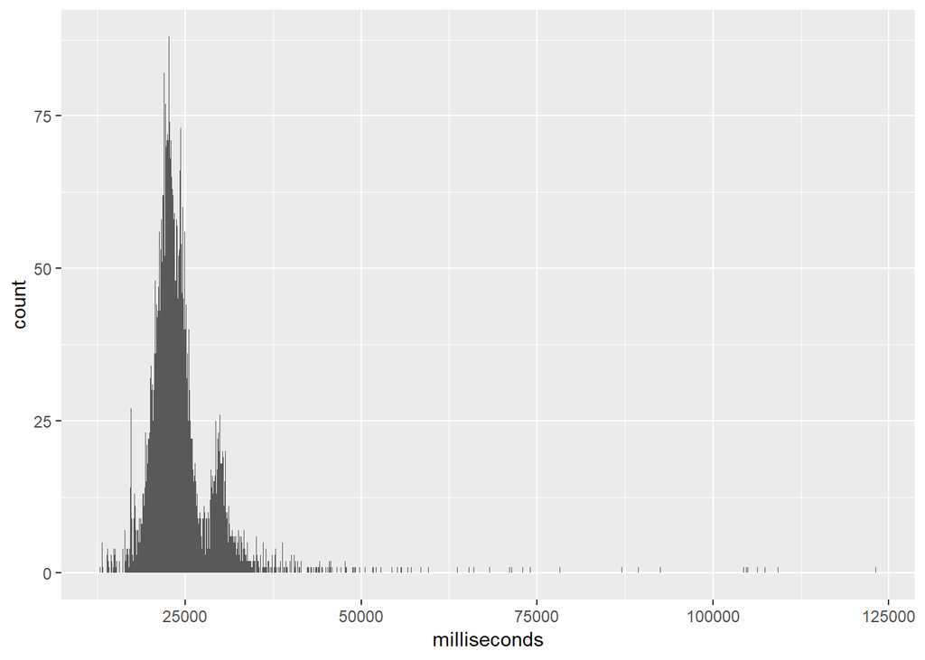

```r
ggplot(pitstops, aes(milliseconds)) + geom_histogram(binwidth = 60)
```

We can now see the peak around 25 seconds as well as a second, smaller spike around 30 seconds. This is likely due to rule changes at some point that either sped up or slowed down the average pit stop duration. It would be interesting, I think, to see how the average time has changed over the years. If we combine some tables together we can look into this further.

## F1 races table

```r
races <- read.csv('data/races.csv', header=FALSE, col.names=c("raceId","year","round","circuitId","name","date","time","url"))
head(races)
```

```
##   raceId year round circuitId                  name       date     time
## 1      1 2009     1         1 Australian Grand Prix 2009-03-29 06:00:00
## 2      2 2009     2         2  Malaysian Grand Prix 2009-04-05 09:00:00
## 3      3 2009     3        17    Chinese Grand Prix 2009-04-19 07:00:00
## 4      4 2009     4         3    Bahrain Grand Prix 2009-04-26 12:00:00
## 5      5 2009     5         4    Spanish Grand Prix 2009-05-10 12:00:00
## 6      6 2009     6         6     Monaco Grand Prix 2009-05-24 12:00:00
##                                                       url
## 1 http://en.wikipedia.org/wiki/2009_Australian_Grand_Prix
## 2  http://en.wikipedia.org/wiki/2009_Malaysian_Grand_Prix
## 3    http://en.wikipedia.org/wiki/2009_Chinese_Grand_Prix
## 4    http://en.wikipedia.org/wiki/2009_Bahrain_Grand_Prix
## 5    http://en.wikipedia.org/wiki/2009_Spanish_Grand_Prix
## 6     http://en.wikipedia.org/wiki/2009_Monaco_Grand_Prix
```

By joining the year data from the races table to the pit stops table by matching the raceId of the pit stop, we can now summarize the pit stop data to a mean value by year.

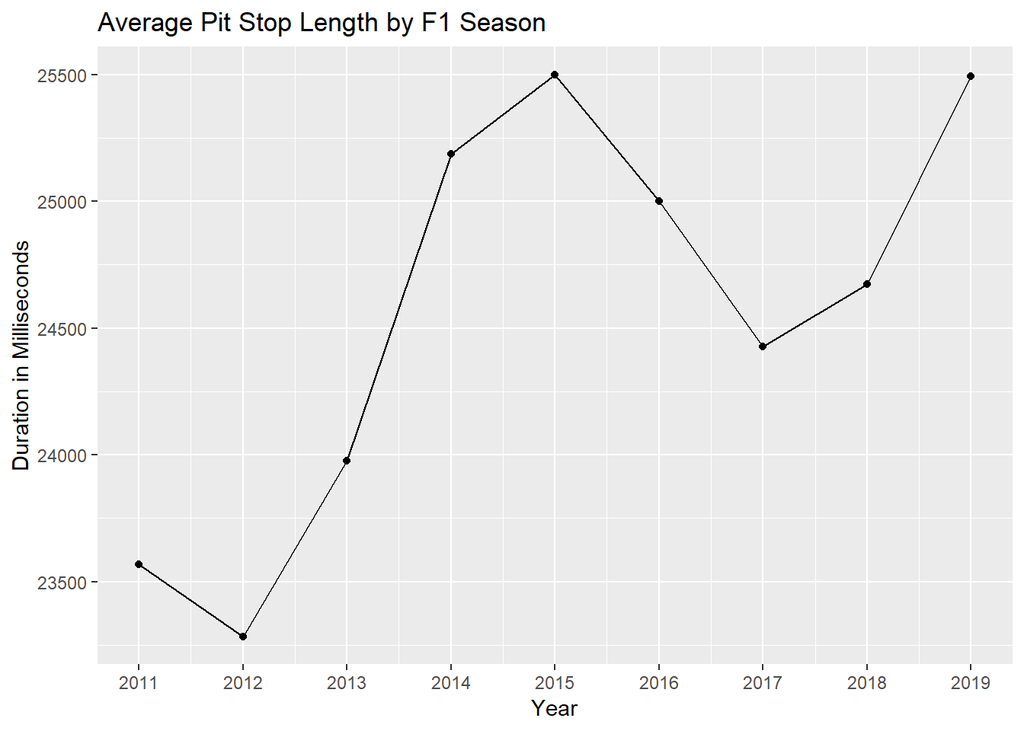

```r
pitstops <- merge(x=pitstops, y=races, by="raceId", all.x = TRUE)
agg <- aggregate(pitstops$milliseconds, by = list(pitstops$year), FUN = mean)
names(agg) <- c("Year","Milliseconds")
ggplot(agg, aes(x=Year, y=Milliseconds)) + geom_line() + geom_point() + labs(y="Duration in Milliseconds", title="Average Pit Stop Length by F1 Season") + scale_x_continuous(breaks=seq(2011,2019,1))
```